# Suicidio en España en relación con el consumo de alcohol y el ejercicio físico.

Claudia Gijón Pigazo, Verónica Barriuso Moreno y Adrián Martín Fuentes

2024-12-01

[REPOSITORIO EN GITHUB](https://github.com/amf1014/VAC_fuentes-de-datos.git)

# Tabla de contenidos

1. Introducción
2. Objetivos
3. Paquetes utilizados
4. Desarrollo
5. Conclusiones finales

## 2. OBJETIVOS

En un primer lugar, vamos a observar y a intentar obtener información de cada conjunto de datos por separado.

Sobre el conjunto de datos sobre el suicidio, observamos las diferencias que hay en el número de suicidios según: - Sexo. - Comunidades autónomas.

Sobre el conjunto de datos sobre el consumo de alcohol, observamos las diferencias que hay en el número de consumo de alcohol según: - Sexo. - Comunidad autónoma.

Sobre el conjunto de datos sobre el ejercicio físico, observamos las diferencias que hay en el número de ejercicio físico que se realiza según: - Sexo. - Comunidades autónomas. - Número de veces a la semana.

Una vez analizado por separado cada conjunto de datos, pasamos a observar si hay relación entre ellos, centrándonos especialmente en:

1.- Relación entre el suicidio y el consumo de alcohol por comunidad autónoma y por sexo. 2.- Relación entre el suicidio y el ejercicio físico por comunidad autónoma y por sexo. 3.- Relación entre el ejercicio físico y el consumo de alcohol por comunidad autónoma y por sexo.

## 3. Paquetes utilizados

A lo largo del seminario utilizamos varios paquetes:

1.library(dplyr)

```r
library(dplyr)
```

2. library(tidyverse)

```r
library(tidyverse)
```

3. library(rjson)

```r
library(rjson)
```

4. library(tidyjson)

```r
library(tidyjson)
```

## 4. Desarrollo

### Carga de datos a usar.

Vamos a trabajar con tres conjuntos de datos en formato json, por tanto cargamos cada uno.

```r
library(dplyr)
library(tidyverse)
library(rjson)
library(tidyjson)
library(ggplot2)
library(mapSpain)
library(sf)
library(patchwork)
library(DT)
suicidio <- fromJSON(file = "INPUT/DATA/Suicidios_por_comunidades.json")
consumo_alcohol <- fromJSON(file = "INPUT/DATA/consumo_de_alcohol.json")
ejercicioFisico <- fromJSON(file = "INPUT/DATA/Ejercicio_fisico.json")
```

### Formateo de datos

Una vez cargados, procedemos a formatear los datos para crear tablas ordenadas con los datos que nos interesan.

Formateo de datos del conjunto de datos de suicidio:

```r
suicidio %>%
  gather_object %>%
  json_types %>%
  count(name,type)
```

```
## # A tibble: 3 × 3
##   name     type       n
##   <chr>    <fct>  <int>
## 1 Data     array    960
## 2 MetaData array    960
## 3 Nombre   string   960
```

```r
suicidio1 <- suicidio %>%
  enter_object(Data) %>%
  gather_array %>%
  spread_all %>%
  select("document.id", "Valor")


suicidio2 <- suicidio %>%
  enter_object(MetaData) %>%
  gather_array %>%
  spread_all %>%
  select("document.id", "Nombre")


suicidio3 <- suicidio1 %>%
  select(c("document.id","Valor")) %>%
  full_join(x = .,
            y = suicidio2 %>%
              select(c("document.id","Nombre")),
            by = c("document.id"))

suicidio4 <- suicidio3 %>%
  mutate(
    sexo = case_when(
      Nombre == "Ambos sexos" ~ "Ambos sexos",
      Nombre == "Hombres" ~ "Hombres",
      Nombre == "Mujeres" ~ "Mujeres",
      TRUE ~ as.character(NA)
    )
  )

suicidio5 <- suicidio4 %>%
  mutate(
    años = case_when(
      Nombre == "Todas las edades" ~ "Todas las edades",
      Nombre == "Menores de 15 años" ~ "Menores de 15 años",
      Nombre == "De 15 a 29 años" ~ "De 15 a 29 años",
      Nombre == "De 30 a 39 años" ~ "De 30 a 39 años",
      Nombre == "De 40 a 44 años" ~ "De 40 a 44 años",
      Nombre == "De 45 a 49 años" ~ "De 45 a 49 años",
      Nombre == "De 50 a 54 años" ~ "De 50 a 54 años",
      Nombre == "De 55 a 59 años" ~ "De 55 a 59 años",
      Nombre == "De 60 a 64 años" ~ "De 60 a 64 años",
      Nombre == "De 65 a 69 años" ~ "De 65 a 69 años",
      Nombre == "De 70 a 74 años" ~ "De 70 a 74 años",
      Nombre == "De 75 a 79 años" ~ "De 75 a 79 años",
      Nombre == "De 80 a 84 años" ~ "De 80 a 84 años",
      Nombre == "De 85 a 89 años" ~ "De 85 a 89 años",
      Nombre == "De 90 a 94 años" ~ "De 90 a 94 años",
      Nombre == "De 95 años y más" ~ "De 95 años y más",
      TRUE ~ as.character(NA)
    )
  )

suicidio6 <- suicidio5 %>%
  mutate(
    comunidades_autonomas = case_when(
      Nombre == "Total" ~ "Total nacional",
      Nombre == "Andalucía" ~ "Andalucía",
      Nombre == "Aragón" ~ "Aragón",
      Nombre == "Asturias, Principado de" ~ "Principado de Asturias",
      Nombre == "Balears, Illes" ~ "Islas Baleares",
      Nombre == "Canarias" ~ "Islas Canarias",
      Nombre == "Cantabria" ~ "Cantabria",
      Nombre == "Castilla y León" ~ "Castilla y León",
      Nombre == "Castilla-La Mancha" ~ "Castilla-La Mancha",
      Nombre == "Cataluña" ~ "Cataluña",
      Nombre == "Comunitat Valenciana" ~ "Comunitat Valenciana",
      Nombre == "Extremadura" ~ "Extremadura",
      Nombre == "Galicia" ~ "Galicia",
      Nombre == "Madrid, Comunidad de" ~ "Madrid",
      Nombre == "Murcia, Región de" ~ "Murcia",
      Nombre == "Navarra, Comunidad Foral de" ~ "Navarra",
      Nombre == "País Vasco" ~ "País Vasco",
      Nombre == "Rioja, La" ~ "La Rioja",
      Nombre == "Ceuta" ~ "Ceuta",
      Nombre == "Melilla" ~ "Melilla",
      TRUE ~ as.character(NA)
    )
  )

suicidio7 <-
  as.data.frame(apply(suicidio6, 2, function(col) col[!is.na(col)]))

suicidio7 <- suicidio7[, -3]

suicidio7$Valor <- suicidio7$Valor[seq(1, length(suicidio7$Valor), by = 3)]

suicidio7$Valor <- suicidio7$Valor[seq(1, length(suicidio7$Valor), by = 16)]

suicidio7$sexo <- suicidio7$sexo[seq(1, length(suicidio7$sexo), by = 16)]

suicidio7$comunidades_autonomas <- suicidio7$comunidades_autonomas[seq(1, length(suicidio7$comunidades_autonomas), by = 16)]


suicidio8 <- suicidio7%>%
  select(-años)


suicidio9 <- suicidio8 %>%
  mutate(
    habitantes = case_when(
      comunidades_autonomas == "Total nacional" & sexo == "Ambos sexos" ~ 48592802,
      comunidades_autonomas == "Total nacional" & sexo == "Hombres" ~ 23807546,
      comunidades_autonomas == "Total nacional" & sexo == "Mujeres" ~ 24785363,
      comunidades_autonomas == "Andalucía" & sexo == "Ambos sexos" ~ 8620120,
      comunidades_autonomas == "Andalucía" & sexo == "Hombres" ~ 4238717,
      comunidades_autonomas == "Andalucía" & sexo == "Mujeres" ~ 4381403,
      comunidades_autonomas == "Aragón" & sexo == "Ambos sexos" ~ 1348918,
      comunidades_autonomas == "Aragón" & sexo == "Hombres" ~ 666949,
      comunidades_autonomas == "Aragón" & sexo == "Mujeres" ~ 681969,
      comunidades_autonomas == "Principado de Asturias" & sexo == "Ambos sexos" ~ 1008876,
      comunidades_autonomas == "Principado de Asturias" & sexo == "Hombres" ~ 481018,
      comunidades_autonomas == "Principado de Asturias" & sexo == "Mujeres" ~ 527858,
      comunidades_autonomas == "Islas Baleares" & sexo == "Ambos sexos" ~ 1231487,
      comunidades_autonomas == "Islas Baleares" & sexo == "Hombres" ~ 614011,
      comunidades_autonomas == "Islas Baleares" & sexo == "Mujeres" ~ 617476,
      comunidades_autonomas == "Islas Canarias" & sexo == "Ambos sexos" ~ 2236013,
      comunidades_autonomas == "Islas Canarias" & sexo == "Hombres" ~ 1103805,
      comunidades_autonomas == "Islas Canarias" & sexo == "Mujeres" ~ 1132208,
      comunidades_autonomas == "Cantabria" & sexo == "Ambos sexos" ~ 591151,
      comunidades_autonomas == "Cantabria" & sexo == "Hombres" ~ 286341,
      comunidades_autonomas == "Cantabria" & sexo == "Mujeres" ~ 304810,
      comunidades_autonomas == "Castilla y León" & sexo == "Ambos sexos" ~ 2389959,
      comunidades_autonomas == "Castilla y León" & sexo == "Hombres" ~ 1175016,
      comunidades_autonomas == "Castilla y León" & sexo == "Mujeres" ~ 1214943,
      comunidades_autonomas == "Castilla-La Mancha" & sexo == "Ambos sexos" ~ 2100523,
      comunidades_autonomas == "Castilla-La Mancha" & sexo == "Hombres" ~ 1053361,
      comunidades_autonomas == "Castilla-La Mancha" & sexo == "Mujeres" ~ 1047162,
      comunidades_autonomas == "Cataluña" & sexo == "Ambos sexos" ~ 8021049,
      comunidades_autonomas == "Cataluña" & sexo == "Hombres" ~ 3948555,
      comunidades_autonomas == "Cataluña" & sexo == "Mujeres" ~ 4072494,
      comunidades_autonomas == "Comunidad Valenciana" & sexo == "Ambos sexos" ~ 5316478,
      comunidades_autonomas == "Comunidad Valenciana" & sexo == "Hombres" ~ 2613918,
      comunidades_autonomas == "Comunidad Valenciana" & sexo == "Mujeres" ~ 2702560,
      comunidades_autonomas == "Extremadura" & sexo == "Ambos sexos" ~ 1053423,
      comunidades_autonomas == "Extremadura" & sexo == "Hombres" ~ 521005,
      comunidades_autonomas == "Extremadura" & sexo == "Mujeres" ~ 532418,
      comunidades_autonomas == "Galicia" & sexo == "Ambos sexos" ~ 2705877,
      comunidades_autonomas == "Galicia" & sexo == "Hombres" ~ 1301669,
      comunidades_autonomas == "Galicia" & sexo == "Mujeres" ~ 1404208,
      comunidades_autonomas == "Madrid" & sexo == "Ambos sexos" ~ 7000621,
      comunidades_autonomas == "Madrid" & sexo == "Hombres" ~ 3352591,
      comunidades_autonomas == "Madrid" & sexo == "Mujeres" ~ 3648030,
      comunidades_autonomas == "Murcia" & sexo == "Ambos sexos" ~ 1569164,
      comunidades_autonomas == "Murcia" & sexo == "Hombres" ~ 786213,
      comunidades_autonomas == "Murcia" & sexo == "Mujeres" ~ 782951,
      comunidades_autonomas == "Navarra" & sexo == "Ambos sexos" ~ 678103,
      comunidades_autonomas == "Navarra" & sexo == "Hombres" ~ 335742,
      comunidades_autonomas == "Navarra" & sexo == "Mujeres" ~ 342361,
      comunidades_autonomas == "País Vasco" & sexo == "Ambos sexos" ~ 2227581,
      comunidades_autonomas == "País Vasco" & sexo == "Hombres" ~ 1083234,
      comunidades_autonomas == "País Vasco" & sexo == "Mujeres" ~ 1144347,
      comunidades_autonomas == "La Rioja" & sexo == "Ambos sexos" ~ 324226,
      comunidades_autonomas == "La Rioja" & sexo == "Hombres" ~160074,
      comunidades_autonomas == "La Rioja" & sexo == "Mujeres" ~ 164152,
      comunidades_autonomas == "Ceuta" & sexo == "Ambos sexos" ~ 83284,
      comunidades_autonomas == "Ceuta" & sexo == "Hombres" ~ 41990,
      comunidades_autonomas == "Ceuta" & sexo == "Mujeres" ~ 41294,
      comunidades_autonomas == "Melilla" & sexo == "Ambos sexos" ~ 86056,
      comunidades_autonomas == "Melilla" & sexo == "Hombres" ~ 43337,
      comunidades_autonomas == "Melilla" & sexo == "Mujeres" ~ 42719,
      TRUE ~ as.numeric(NA)
    )
  )


suicidio10 <- suicidio9 %>%
  mutate(
    porcentaje_suicidios = (as.numeric(Valor) / habitantes) * 100
  )

suicidio10 <- suicidio10 %>% slice(1:60)

datatable(suicidio10, options = list(pageLength = 10))
```

|  | document.id | Valor | sexo | comunidades_autonomas | habitantes | porcentaje_suicidios |
| --- | --- | --- | --- | --- | --- | --- |
| 1 | 1 | 4227 | Ambos sexos | Total nacional | 48592802 | 0.008698819220179977 |
| 2 | 1 | 3126 | Hombres | Total nacional | 23807546 | 0.01313029070698845 |
| 3 | 1 | 1101 | Mujeres | Total nacional | 24785363 | 0.0044421378859773 |
| 4 | 2 | 844 | Ambos sexos | Andalucía | 8620120 | 0.009791046992385257 |
| 5 | 2 | 661 | Hombres | Andalucía | 4238717 | 0.0155943414009475 |
| 6 | 2 | 183 | Mujeres | Andalucía | 4381403 | 0.004176744298572854 |
| 7 | 3 | 119 | Ambos sexos | Aragón | 1348918 | 0.008821885392588727 |
| 8 | 3 | 91 | Hombres | Aragón | 666949 | 0.01364422167212186 |
| 9 | 3 | 28 | Mujeres | Aragón | 681969 | 0.004105758472892462 |
| 10 | 4 | 124 | Ambos sexos | Principado de Asturias | 1008876 | 0.0122909059190624 |

[output cut: 50 more lines]

Formateo de datos del conjunto de datos del consumo de alcohol:

```r
consumo_alcohol_tiposresum<-consumo_alcohol %>%
  gather_object %>%
  json_types %>%
  count(name, type)
consumo_alcohol_tiposresum
```

```
## # A tibble: 3 × 3
##   name     type       n
##   <chr>    <fct>  <int>
## 1 Data     array    240
## 2 MetaData array    240
## 3 Nombre   string   240
```

```r
#consumo_alcohol_tiposresum$name[3]

consumo_alcohol1<-consumo_alcohol %>%
  enter_object(Data) %>%
  gather_array %>%
  spread_all %>%
  select("document.id", "Valor")

consumo_alcohol1
```

```
## # A tbl_json: 240 x 3 tibble with a "JSON" attribute
##    ..JSON                 document.id   Valor
##    <chr>                        <int>   <dbl>
##  1 "{\"Valor\":39974...."           1 39974.
##  2 "{\"Valor\":26139...."           2 26140.
##  3 "{\"Valor\":13774...."           3 13774.
##  4 "{\"Valor\":59.9}"               4    59.9
##  5 "{\"Valor\":7096.4..."           5  7096.
##  6 "{\"Valor\":3775.2..."           6  3775.
##  7 "{\"Valor\":3305.9..."           7  3306.
##  8 "{\"Valor\":15.3}"               8    15.3
##  9 "{\"Valor\":1121.4..."           9  1121.
## 10 "{\"Valor\":667.3}"             10   667.
## # ℹ 230 more rows
```

```r
consumo_alcohol2<-consumo_alcohol %>%
  enter_object(MetaData) %>%
  gather_array %>%
  spread_all %>%
  select("document.id", "Nombre")

consumo_alcohol2
```

```
## # A tbl_json: 720 x 3 tibble with a "JSON" attribute
##    ..JSON                 document.id Nombre
##    <chr>                        <int> <chr>
##  1 "{\"T3_Variable\":..."           1 Ambos sexos
##  2 "{\"T3_Variable\":..."           1 Total
##  3 "{\"T3_Variable\":..."           1 TOTAL
##  4 "{\"T3_Variable\":..."           2 Ambos sexos
##  5 "{\"T3_Variable\":..."           2 Total
##  6 "{\"T3_Variable\":..."           2 Sí ha consumido
##  7 "{\"T3_Variable\":..."           3 Ambos sexos
##  8 "{\"T3_Variable\":..."           3 Total
##  9 "{\"T3_Variable\":..."           3 No ha consumido
## 10 "{\"T3_Variable\":..."           4 Ambos sexos
## # ℹ 710 more rows
```

```r
consumo_alcohol3 <- consumo_alcohol1 %>%
  select(c("document.id","Valor")) %>%
  full_join(x = .,
            y = consumo_alcohol2 %>%
              select(c("document.id","Nombre")),
            by = c("document.id"))

#view(consumo_alcohol3)

consumo_alcohol4 <- consumo_alcohol3 %>%
  mutate(
    sexo = case_when(
      Nombre == "Ambos sexos" ~ "Ambos sexos",
      Nombre == "Hombres" ~ "Hombres",
      Nombre == "Mujeres" ~ "Mujeres",
      TRUE ~ as.character(NA)
    )
  )
consumo_alcohol5 <- consumo_alcohol4 %>%
  mutate(
    comunidades_autonomas = case_when(
      Nombre == "Total" ~ "Total Nacional",
      Nombre == "Andalucía" ~ "Andalucía",
      Nombre == "Aragón" ~ "Aragón",
      Nombre == "Asturias (Principado de)" ~ "Principado de Asturias",
      Nombre == "Balears (Illes)" ~ "Islas Baleares",
      Nombre == "Canarias" ~ "Islas Canarias",
      Nombre == "Cantabria" ~ "Cantabria",
      Nombre == "Castilla y León" ~ "Castilla y León",
      Nombre == "Castilla-La Mancha" ~ "Castilla-La Mancha",
      Nombre == "Cataluña" ~ "Cataluña",
      Nombre == "Comunitat Valenciana" ~ "Comunitat Valenciana",
      Nombre == "Extremadura" ~ "Extremadura",
      Nombre == "Galicia" ~ "Galicia",
      Nombre == "Madrid (Comunidad de)" ~ "Madrid",
      Nombre == "Murcia (Región de)" ~ "Murcia",
      Nombre == "Navarra (Comunidad Foral de)" ~ "Navarra",
      Nombre == "País Vasco" ~ "País Vasco",
      Nombre == "Rioja (La)" ~ "La Rioja",
      Nombre == "Ceuta (Ciudad Autónoma de)" ~ "Ceuta",
      Nombre == "Melilla (Ciudad Autónoma de)" ~ "Melilla",
      TRUE ~ as.character(NA)
    )
  )

consumo_alcohol6 <- consumo_alcohol5 %>%
  mutate(
    años = case_when(
      Nombre == "TOTAL" ~ "Total consumido",
      Nombre == "Si ha consumido" ~ "Si ha consumido",
      Nombre == "No ha consumido" ~ "No ha consumido",
      Nombre == "No consta" ~ "No consta",
      TRUE ~ as.character(NA)
    )
  )
head(consumo_alcohol6)
```

```
## # A tibble: 6 × 6
##   document.id  Valor Nombre          sexo        comunidades_autonomas años
##         <int>  <dbl> <chr>           <chr>       <chr>                 <chr>
## 1           1 39974. Ambos sexos     Ambos sexos <NA>                  <NA>
## 2           1 39974. Total           <NA>        Total Nacional        <NA>
## 3           1 39974. TOTAL           <NA>        <NA>                  Total co…
## 4           2 26140. Ambos sexos     Ambos sexos <NA>                  <NA>
## 5           2 26140. Total           <NA>        Total Nacional        <NA>
## 6           2 26140. Sí ha consumido <NA>        <NA>                  <NA>
```

```r
consumo_alcohol7 <-
  as.data.frame(apply(consumo_alcohol6, 2, function(col) col[!is.na(col)]))

head(consumo_alcohol7)
```

```
##   document.id   Valor          Nombre        sexo comunidades_autonomas
## 1           1 39974.1     Ambos sexos Ambos sexos        Total Nacional
## 2           1 39974.1           Total Ambos sexos        Total Nacional
## 3           1 39974.1           TOTAL Ambos sexos        Total Nacional
## 4           2 26139.8     Ambos sexos Ambos sexos        Total Nacional
## 5           2 26139.8           Total Ambos sexos             Andalucía
## 6           2 26139.8 Sí ha consumido Ambos sexos             Andalucía
##              años
## 1 Total consumido
## 2 No ha consumido
## 3       No consta
## 4 Total consumido
## 5 No ha consumido
## 6       No consta
```

```r
consumo_alcohol7$Valor <- consumo_alcohol7$Valor[seq(1, length(consumo_alcohol7$Valor), by = 3)]
```

Formateo de datos del conjunto de datos de ejercicio físico:

```r
tiposEjercicioFisico_visiongeneral<-ejercicioFisico%>%
  gather_object %>%
  json_types

tiposEjercicioFisico_visiongeneral
```

```
## # A tbl_json: 1,080 x 4 tibble with a "JSON" attribute
##    ..JSON                 document.id name     type
##    <chr>                        <int> <chr>    <fct>
##  1 "\"Ambos sexos, T..."            1 Nombre   string
##  2 "[{\"T3_Variable\"..."           1 MetaData array
##  3 "[{\"Valor\":100}]"              1 Data     array
##  4 "\"Ambos sexos, T..."            2 Nombre   string
##  5 "[{\"T3_Variable\"..."           2 MetaData array
##  6 "[{\"Valor\":50.72..."           2 Data     array
##  7 "\"Ambos sexos, T..."            3 Nombre   string
##  8 "[{\"T3_Variable\"..."           3 MetaData array
##  9 "[{\"Valor\":13.21..."           3 Data     array
## 10 "\"Ambos sexos, T..."            4 Nombre   string
## # ℹ 1,070 more rows
```

```r
tiposEjercicioFisico <- ejercicioFisico %>%
  gather_object %>%
  json_types %>%
  count(name, type)

tiposEjercicioFisico
```

```
## # A tibble: 3 × 3
##   name     type       n
##   <chr>    <fct>  <int>
## 1 Data     array    360
## 2 MetaData array    360
## 3 Nombre   string   360
```

```r
nombresEjercicioFisico <- ejercicioFisico %>%
  enter_object(Nombre)

#Con la línea siguiente busco interpretar como se guardan los datos.
nombresEjercicioFisico
```

```
## # A tbl_json: 360 x 2 tibble with a "JSON" attribute
##    ..JSON                document.id
##    <chr>                       <int>
##  1 "\"Ambos sexos, T..."           1
##  2 "\"Ambos sexos, T..."           2
##  3 "\"Ambos sexos, T..."           3
##  4 "\"Ambos sexos, T..."           4
##  5 "\"Ambos sexos, T..."           5
##  6 "\"Ambos sexos, T..."           6
##  7 "\"Ambos sexos, A..."           7
##  8 "\"Ambos sexos, A..."           8
##  9 "\"Ambos sexos, A..."           9
## 10 "\"Ambos sexos, A..."          10
## # ℹ 350 more rows
```

```r
#Estructurar los datos
ejercicioFisicoData <- ejercicioFisico %>%
  enter_object(Data) %>%
  gather_array %>%
  spread_all%>%
  select(-array.index)

ejercicioFisicoMetaData <-ejercicioFisico %>%
  enter_object(MetaData) %>%
  gather_array %>%
  spread_all %>%
  select(document.id, Nombre)

ejercicioFisicoData
```

```
## # A tbl_json: 360 x 3 tibble with a "JSON" attribute
##    ..JSON              document.id  Valor
##    <chr>                     <int>  <dbl>
##  1 "{\"Valor\":100}"             1 100
##  2 "{\"Valor\":50.72}"           2  50.7
##  3 "{\"Valor\":13.21}"           3  13.2
##  4 "{\"Valor\":18.14}"           4  18.1
##  5 "{\"Valor\":10.25}"           5  10.2
##  6 "{\"Valor\":7.68}"            6   7.68
##  7 "{\"Valor\":100}"             7 100
##  8 "{\"Valor\":52.22}"           8  52.2
##  9 "{\"Valor\":11.68}"           9  11.7
## 10 "{\"Valor\":18.65}"          10  18.6
## # ℹ 350 more rows
```

```r
ejercicioFisicoMetaData
```

```
## # A tbl_json: 1,080 x 3 tibble with a "JSON" attribute
##    ..JSON                 document.id Nombre
##    <chr>                        <int> <chr>
##  1 "{\"T3_Variable\":..."           1 Ambos sexos
##  2 "{\"T3_Variable\":..."           1 Total
##  3 "{\"T3_Variable\":..."           1 TOTAL
##  4 "{\"T3_Variable\":..."           2 Ambos sexos
##  5 "{\"T3_Variable\":..."           2 Total
##  6 "{\"T3_Variable\":..."           2 Ninguno
##  7 "{\"T3_Variable\":..."           3 Ambos sexos
##  8 "{\"T3_Variable\":..."           3 Total
##  9 "{\"T3_Variable\":..."           3 1 o 2 días a la semana
## 10 "{\"T3_Variable\":..."           4 Ambos sexos
## # ℹ 1,070 more rows
```

```r
ejercicioFisicoUnion <- left_join(ejercicioFisicoMetaData, ejercicioFisicoData, by="document.id")
ejercicioFisicoUnion
```

```
## # A tibble: 1,080 × 3
##    document.id Nombre                 Valor
##          <int> <chr>                  <dbl>
##  1           1 Ambos sexos            100
##  2           1 Total                  100
##  3           1 TOTAL                  100
##  4           2 Ambos sexos             50.7
##  5           2 Total                   50.7
##  6           2 Ninguno                 50.7
##  7           3 Ambos sexos             13.2
##  8           3 Total                   13.2
##  9           3 1 o 2 días a la semana  13.2
## 10           4 Ambos sexos             18.1
## # ℹ 1,070 more rows
```

```r
ejercicioFisicoUnion <- ejercicioFisicoUnion %>%
  mutate(
    Sexo = case_when(
      Nombre == "Ambos sexos" ~ "Ambos sexos",
      Nombre == "Hombres" ~ "Hombres",
      Nombre == "Mujeres" ~ "Mujeres",
      TRUE ~ as.character(NA)
    ),
    `Comunidades autonomas` = case_when(
      Nombre == "Total" ~ "Total Nacional",
      Nombre == "Andalucía" ~ "Andalucía",
      Nombre == "Aragón" ~ "Aragón",
      Nombre == "Asturias (Principado de)" ~ "Principado de Asturias",
      Nombre == "Balears (Illes)" ~ "Islas Baleares",
      Nombre == "Canarias" ~ "Islas Canarias",
      Nombre == "Cantabria" ~ "Cantabria",
      Nombre == "Castilla y León" ~ "Castilla y León",
      Nombre == "Castilla-La Mancha" ~ "Castilla-La Mancha",
      Nombre == "Cataluña" ~ "Cataluña",
      Nombre == "Comunitat Valenciana" ~ "Comunitat Valenciana",
      Nombre == "Extremadura" ~ "Extremadura",
      Nombre == "Galicia" ~ "Galicia",
      Nombre == "Madrid (Comunidad de)" ~ "Madrid",
      Nombre == "Murcia (Región de)" ~ "Murcia",
      Nombre == "Navarra (Comunidad Foral de)" ~ "Navarra",
      Nombre == "País Vasco" ~ "País Vasco",
      Nombre == "Rioja (La)" ~ "La Rioja",
      Nombre == "Ceuta (Ciudad Autónoma de)" ~ "Ceuta",
      Nombre == "Melilla (Ciudad Autónoma de)" ~ "Melilla",
      TRUE ~ as.character(NA)
    ),
    `Frecuencia de ejercicio` = case_when(
      Nombre == "TOTAL" ~ "TOTAL",
      Nombre == "Ninguno" ~ "Ninguno",
      Nombre == "1 o 2 días a la semana" ~ "1 o 2 días a la semana",
      Nombre == "3 o 4 días a la semana" ~ "3 o 4 días a la semana",
      Nombre == "5 o 6 días a la semana" ~ "5 o 6 días a la semana",
      Nombre == "7 días a la semana" ~ "7 días a la semana",
      TRUE ~ as.character(NA)
    )
  )

ejercicioFisicoUnion
```

```
## # A tibble: 1,080 × 6
##    document.id Nombre  Valor Sexo  Comunidades autonoma…¹ Frecuencia de ejerci…²
##          <int> <chr>   <dbl> <chr> <chr>                  <chr>
##  1           1 Ambos … 100   Ambo… <NA>                   <NA>
##  2           1 Total   100   <NA>  Total Nacional         <NA>
##  3           1 TOTAL   100   <NA>  <NA>                   TOTAL
##  4           2 Ambos …  50.7 Ambo… <NA>                   <NA>
##  5           2 Total    50.7 <NA>  Total Nacional         <NA>
##  6           2 Ninguno  50.7 <NA>  <NA>                   Ninguno
##  7           3 Ambos …  13.2 Ambo… <NA>                   <NA>
##  8           3 Total    13.2 <NA>  Total Nacional         <NA>
##  9           3 1 o 2 …  13.2 <NA>  <NA>                   1 o 2 días a la semana
## 10           4 Ambos …  18.1 Ambo… <NA>                   <NA>
## # ℹ 1,070 more rows
## # ℹ abbreviated names: ¹`Comunidades autonomas`, ²`Frecuencia de ejercicio`
```

```r
ejercicioFisicoUnion <- ejercicioFisicoUnion %>%
  fill(Sexo, `Comunidades autonomas`, `Frecuencia de ejercicio`, .direction = "up")

ejercicioFisicoUnion
```

```
## # A tibble: 1,080 × 6
##    document.id Nombre  Valor Sexo  Comunidades autonoma…¹ Frecuencia de ejerci…²
##          <int> <chr>   <dbl> <chr> <chr>                  <chr>
##  1           1 Ambos … 100   Ambo… Total Nacional         TOTAL
##  2           1 Total   100   Ambo… Total Nacional         TOTAL
##  3           1 TOTAL   100   Ambo… Total Nacional         TOTAL
##  4           2 Ambos …  50.7 Ambo… Total Nacional         Ninguno
##  5           2 Total    50.7 Ambo… Total Nacional         Ninguno
##  6           2 Ninguno  50.7 Ambo… Total Nacional         Ninguno
##  7           3 Ambos …  13.2 Ambo… Total Nacional         1 o 2 días a la semana
##  8           3 Total    13.2 Ambo… Total Nacional         1 o 2 días a la semana
##  9           3 1 o 2 …  13.2 Ambo… Total Nacional         1 o 2 días a la semana
## 10           4 Ambos …  18.1 Ambo… Total Nacional         3 o 4 días a la semana
## # ℹ 1,070 more rows
## # ℹ abbreviated names: ¹`Comunidades autonomas`, ²`Frecuencia de ejercicio`
```

```r
ejercicioFisicoUnion <- filter(ejercicioFisicoUnion, ejercicioFisicoUnion$Nombre == ejercicioFisicoUnion$Sexo)

ejercicioFisicoUnion
```

```
## # A tibble: 360 × 6
##    document.id Nombre  Valor Sexo  Comunidades autonoma…¹ Frecuencia de ejerci…²
##          <int> <chr>   <dbl> <chr> <chr>                  <chr>
##  1           1 Ambos… 100    Ambo… Total Nacional         TOTAL
##  2           2 Ambos…  50.7  Ambo… Total Nacional         Ninguno
##  3           3 Ambos…  13.2  Ambo… Total Nacional         1 o 2 días a la semana
##  4           4 Ambos…  18.1  Ambo… Total Nacional         3 o 4 días a la semana
##  5           5 Ambos…  10.2  Ambo… Total Nacional         5 o 6 días a la semana
##  6           6 Ambos…   7.68 Ambo… Total Nacional         7 días a la semana
##  7           7 Ambos… 100    Ambo… Andalucía              TOTAL
##  8           8 Ambos…  52.2  Ambo… Andalucía              Ninguno
##  9           9 Ambos…  11.7  Ambo… Andalucía              1 o 2 días a la semana
## 10          10 Ambos…  18.6  Ambo… Andalucía              3 o 4 días a la semana
## # ℹ 350 more rows
## # ℹ abbreviated names: ¹`Comunidades autonomas`, ²`Frecuencia de ejercicio`
```

```r
ejercicioFisicoUnion <- ejercicioFisicoUnion %>%
  select(-Nombre,-document.id)%>%
  rename("Miles de personas"=Valor)

ejercicioFisicoUnion
```

```
## # A tibble: 360 × 4
##    `Miles de personas` Sexo        Comunidades autonoma…¹ Frecuencia de ejerci…²
##                  <dbl> <chr>       <chr>                  <chr>
##  1              100    Ambos sexos Total Nacional         TOTAL
##  2               50.7  Ambos sexos Total Nacional         Ninguno
##  3               13.2  Ambos sexos Total Nacional         1 o 2 días a la semana
##  4               18.1  Ambos sexos Total Nacional         3 o 4 días a la semana
##  5               10.2  Ambos sexos Total Nacional         5 o 6 días a la semana
##  6                7.68 Ambos sexos Total Nacional         7 días a la semana
##  7              100    Ambos sexos Andalucía              TOTAL
##  8               52.2  Ambos sexos Andalucía              Ninguno
##  9               11.7  Ambos sexos Andalucía              1 o 2 días a la semana
## 10               18.6  Ambos sexos Andalucía              3 o 4 días a la semana
## # ℹ 350 more rows
## # ℹ abbreviated names: ¹`Comunidades autonomas`, ²`Frecuencia de ejercicio`
```

```r
totalPersonasComunidad <- ejercicioFisicoUnion %>%
  filter(`Frecuencia de ejercicio` == "TOTAL") %>%
  select(`Comunidades autonomas`, `Total personas según la comunidad` = `Miles de personas`)

totalPersonasComunidad
```

```
## # A tibble: 60 × 2
##    `Comunidades autonomas` `Total personas según la comunidad`
##    <chr>                                                 <dbl>
##  1 Total Nacional                                          100
##  2 Andalucía                                               100
##  3 Aragón                                                  100
##  4 Principado de Asturias                                  100
##  5 Islas Baleares                                          100
##  6 Islas Canarias                                          100
##  7 Cantabria                                               100
##  8 Castilla y León                                         100
##  9 Castilla-La Mancha                                      100
## 10 Cataluña                                                100
## # ℹ 50 more rows
```

```r
duplicated(totalPersonasComunidad)
```

```
##  [1] FALSE FALSE FALSE FALSE FALSE FALSE FALSE FALSE FALSE FALSE FALSE FALSE
## [13] FALSE FALSE FALSE FALSE FALSE FALSE FALSE FALSE  TRUE  TRUE  TRUE  TRUE
## [25]  TRUE  TRUE  TRUE  TRUE  TRUE  TRUE  TRUE  TRUE  TRUE  TRUE  TRUE  TRUE
## [37]  TRUE  TRUE  TRUE  TRUE  TRUE  TRUE  TRUE  TRUE  TRUE  TRUE  TRUE  TRUE
## [49]  TRUE  TRUE  TRUE  TRUE  TRUE  TRUE  TRUE  TRUE  TRUE  TRUE  TRUE  TRUE
```

```r
totalPersonasComunidad <- totalPersonasComunidad %>%
  distinct(`Comunidades autonomas`, .keep_all = TRUE)

duplicated(totalPersonasComunidad)
```

```
##  [1] FALSE FALSE FALSE FALSE FALSE FALSE FALSE FALSE FALSE FALSE FALSE FALSE
## [13] FALSE FALSE FALSE FALSE FALSE FALSE FALSE FALSE
```

```r
ejercicioFisicoUnion <- left_join(ejercicioFisicoUnion, totalPersonasComunidad, by="Comunidades autonomas")
```

### Análisis de datos

Una vez formateados los datos, pasamos a analizarlos, calculando medias y porcentajes:

```r
suicidio_por_sexo <- suicidio7 %>%
  group_by(sexo) %>%
  summarize(suicidio_medio_sexo=mean(as.numeric(Valor), na.rm = TRUE))

#view(suicidio_por_sexo)

suicidio_por_comunidad <- suicidio7 %>%
  group_by(comunidades_autonomas) %>%
  summarize(suicidio_medio_comunidad=mean(as.numeric(Valor), na.rm = TRUE))

#view(suicidio_por_comunidad)

suicidio_por_edad <- suicidio7 %>%
  group_by(años) %>%
  summarize(suicidio_medio_edad=mean(as.numeric(Valor), na.rm = TRUE))

#view(suicidio_por_edad)

suicidio_por_sexo_comunidad <- suicidio7 %>%
  group_by(sexo, comunidades_autonomas) %>%
  summarize(suicidio_medio_sexo_comunidad=mean(as.numeric(Valor), na.rm = TRUE))
consumo_por_sexo<- consumo_alcohol7 %>%
  group_by(sexo) %>%
  summarize(consumo_medio_sexo=mean(as.numeric(Valor), na.rm = TRUE))

#view(consumo_por_sexo)

consumo_por_comunidad <- consumo_alcohol7 %>%
  group_by(comunidades_autonomas) %>%
  summarize(consumo_medio_comunidad = mean(as.numeric(Valor), na.rm = TRUE))

#view(consumo_por_comunidad)

consumo_por_sexo_comunidad <- consumo_alcohol7 %>%
  group_by(sexo, comunidades_autonomas) %>%
  summarize(consumo_medio_sexo_comunidad = mean(as.numeric(Valor), na.rm = TRUE))
#view(consumo_por_sexo_comunidad)
```

```r
ejercicioFisicoUnion <- ejercicioFisicoUnion %>%
  mutate(
    Ratio = `Miles de personas` / `Total personas según la comunidad`,
    Porcentaje = Ratio * 100
  )%>%
  select(-`Total personas según la comunidad`)

frecuenciaNadaYMaxEjercicioComunidad <- ejercicioFisicoUnion%>%
  mutate(
    NadaMax = case_when(
      `Frecuencia de ejercicio` == "Ninguno" ~ `Ratio`,
      `Frecuencia de ejercicio` == "7 días a la semana" ~ `Ratio`,
      TRUE ~ as.double(NA)
    ))%>%
  select(`Comunidades autonomas`,Sexo,`Frecuencia de ejercicio`,`Ratio`, NadaMax) %>%
  filter(!is.na(NadaMax))

frecuenciaNadaYMaxEjercicioComunidad
```

```
## # A tibble: 120 × 5
##    `Comunidades autonomas` Sexo        `Frecuencia de ejercicio`  Ratio NadaMax
##    <chr>                   <chr>       <chr>                      <dbl>   <dbl>
##  1 Total Nacional          Ambos sexos Ninguno                   0.507   0.507
##  2 Total Nacional          Ambos sexos 7 días a la semana        0.0768  0.0768
##  3 Andalucía               Ambos sexos Ninguno                   0.522   0.522
##  4 Andalucía               Ambos sexos 7 días a la semana        0.0676  0.0676
##  5 Aragón                  Ambos sexos Ninguno                   0.535   0.535
##  6 Aragón                  Ambos sexos 7 días a la semana        0.0819  0.0819
##  7 Principado de Asturias  Ambos sexos Ninguno                   0.340   0.340
##  8 Principado de Asturias  Ambos sexos 7 días a la semana        0.0529  0.0529
##  9 Islas Baleares          Ambos sexos Ninguno                   0.473   0.473
## 10 Islas Baleares          Ambos sexos 7 días a la semana        0.162   0.162
## # ℹ 110 more rows
```

```r
ComparacionNadaYMaxEjercicio <- frecuenciaNadaYMaxEjercicioComunidad%>%
  spread(`Frecuencia de ejercicio`, Ratio)%>%
  fill(`7 días a la semana`,`Ninguno`, .direction = "up")%>%
  filter(NadaMax==`7 días a la semana`)%>%
  mutate(
    `Comparacion nada y máximo ejercicio por comunidad y sexo` = `Ninguno` - `7 días a la semana`
  )%>%
  select(-NadaMax)

ComparacionNadaYMaxEjercicio <- ComparacionNadaYMaxEjercicio%>%
  mutate(
    `Porcentaje nada y máximo ejercicio` = ComparacionNadaYMaxEjercicio$`Comparacion nada y máximo ejercicio por comunidad y sexo`*100)

ComparacionNadaYMaxEjercicio
```

```
## # A tibble: 60 × 6
##    `Comunidades autonomas` Sexo        `7 días a la semana` Ninguno
##    <chr>                   <chr>                      <dbl>   <dbl>
##  1 Andalucía               Ambos sexos               0.0676   0.522
##  2 Andalucía               Hombres                   0.0752   0.468
##  3 Andalucía               Mujeres                   0.0603   0.574
##  4 Aragón                  Ambos sexos               0.0819   0.535
##  5 Aragón                  Hombres                   0.0694   0.546
##  6 Aragón                  Mujeres                   0.094    0.523
##  7 Cantabria               Ambos sexos               0.0377   0.654
##  8 Cantabria               Hombres                   0.0631   0.590
##  9 Cantabria               Mujeres                   0.0139   0.713
## 10 Castilla-La Mancha      Ambos sexos               0.0838   0.58
## # ℹ 50 more rows
## # ℹ 2 more variables:
## #   `Comparacion nada y máximo ejercicio por comunidad y sexo` <dbl>,
## #   `Porcentaje nada y máximo ejercicio` <dbl>
```

```r
NadaFrenteMaxEjercicioHombres <- ComparacionNadaYMaxEjercicio%>%
  filter(Sexo=="Hombres")%>%
  select(-`Comparacion nada y máximo ejercicio por comunidad y sexo`)

NadaFrenteMaxEjercicioHombres
```

```
## # A tibble: 20 × 5
##    `Comunidades autonomas` Sexo    `7 días a la semana` Ninguno
##    <chr>                   <chr>                  <dbl>   <dbl>
##  1 Andalucía               Hombres               0.0752   0.468
##  2 Aragón                  Hombres               0.0694   0.546
##  3 Cantabria               Hombres               0.0631   0.590
##  4 Castilla-La Mancha      Hombres               0.0901   0.536
##  5 Castilla y León         Hombres               0.133    0.444
##  6 Cataluña                Hombres               0.0704   0.463
##  7 Ceuta                   Hombres               0.0074   0.566
##  8 Comunitat Valenciana    Hombres               0.0802   0.463
##  9 Extremadura             Hombres               0.0558   0.609
## 10 Galicia                 Hombres               0.0458   0.583
## 11 Islas Baleares          Hombres               0.189    0.449
## 12 Islas Canarias          Hombres               0.0308   0.480
## 13 La Rioja                Hombres               0.131    0.465
## 14 Madrid                  Hombres               0.0991   0.395
## 15 Melilla                 Hombres               0.0085   0.425
## 16 Murcia                  Hombres               0.0573   0.421
## 17 Navarra                 Hombres               0.224    0.301
## 18 País Vasco              Hombres               0.134    0.443
## 19 Principado de Asturias  Hombres               0.0487   0.343
## 20 Total Nacional          Hombres               0.0839   0.465
## # ℹ 1 more variable: `Porcentaje nada y máximo ejercicio` <dbl>
```

```r
NadaFrenteMaxEjercicioMujeres <- ComparacionNadaYMaxEjercicio%>%
  filter(Sexo=="Mujeres")%>%
  select(-`Comparacion nada y máximo ejercicio por comunidad y sexo`)

NadaFrenteMaxEjercicioMujeres
```

```
## # A tibble: 20 × 5
##    `Comunidades autonomas` Sexo    `7 días a la semana` Ninguno
##    <chr>                   <chr>                  <dbl>   <dbl>
##  1 Andalucía               Mujeres               0.0603   0.574
##  2 Aragón                  Mujeres               0.094    0.523
##  3 Cantabria               Mujeres               0.0139   0.713
##  4 Castilla-La Mancha      Mujeres               0.0775   0.624
##  5 Castilla y León         Mujeres               0.167    0.443
##  6 Cataluña                Mujeres               0.0629   0.551
##  7 Ceuta                   Mujeres               0.0127   0.735
##  8 Comunitat Valenciana    Mujeres               0.055    0.561
##  9 Extremadura             Mujeres               0.0585   0.608
## 10 Galicia                 Mujeres               0.0338   0.646
## 11 Islas Baleares          Mujeres               0.135    0.496
## 12 Islas Canarias          Mujeres               0.0339   0.548
## 13 La Rioja                Mujeres               0.138    0.472
## 14 Madrid                  Mujeres               0.0684   0.549
## 15 Melilla                 Mujeres               0.0042   0.578
## 16 Murcia                  Mujeres               0.054    0.466
## 17 Navarra                 Mujeres               0.150    0.403
## 18 País Vasco              Mujeres               0.104    0.485
## 19 Principado de Asturias  Mujeres               0.0567   0.337
## 20 Total Nacional          Mujeres               0.0701   0.548
## # ℹ 1 more variable: `Porcentaje nada y máximo ejercicio` <dbl>
```

```r
NadaFrenteMaxEjercicioAmbos <- ComparacionNadaYMaxEjercicio%>%
  filter(Sexo=="Ambos sexos")%>%
  select(-`Comparacion nada y máximo ejercicio por comunidad y sexo`)

NadaFrenteMaxEjercicioAmbos
```

```
## # A tibble: 20 × 5
##    `Comunidades autonomas` Sexo        `7 días a la semana` Ninguno
##    <chr>                   <chr>                      <dbl>   <dbl>
##  1 Andalucía               Ambos sexos               0.0676   0.522
##  2 Aragón                  Ambos sexos               0.0819   0.535
##  3 Cantabria               Ambos sexos               0.0377   0.654
##  4 Castilla-La Mancha      Ambos sexos               0.0838   0.58
##  5 Castilla y León         Ambos sexos               0.150    0.443
##  6 Cataluña                Ambos sexos               0.0665   0.509
##  7 Ceuta                   Ambos sexos               0.01     0.650
##  8 Comunitat Valenciana    Ambos sexos               0.0673   0.513
##  9 Extremadura             Ambos sexos               0.0572   0.608
## 10 Galicia                 Ambos sexos               0.0395   0.616
## 11 Islas Baleares          Ambos sexos               0.162    0.473
## 12 Islas Canarias          Ambos sexos               0.0324   0.515
## 13 La Rioja                Ambos sexos               0.135    0.469
## 14 Madrid                  Ambos sexos               0.083    0.476
## 15 Melilla                 Ambos sexos               0.0064   0.502
## 16 Murcia                  Ambos sexos               0.0557   0.444
## 17 Navarra                 Ambos sexos               0.187    0.352
## 18 País Vasco              Ambos sexos               0.118    0.465
## 19 Principado de Asturias  Ambos sexos               0.0529   0.340
## 20 Total Nacional          Ambos sexos               0.0768   0.507
## # ℹ 1 more variable: `Porcentaje nada y máximo ejercicio` <dbl>
```

```r
DiferenciaDeActividadEntreAmbosSexosComunidad <- full_join(NadaFrenteMaxEjercicioMujeres,NadaFrenteMaxEjercicioHombres, by = c("Comunidades autonomas"))%>%
  rename(`Porcentaje Mujeres` =`Porcentaje nada y máximo ejercicio.x`, `Porcentaje Hombres` =`Porcentaje nada y máximo ejercicio.y`, ` Mujeres: 7 días a la semana` =`7 días a la semana.x`, `Hombres: 7 días a la semana` =`7 días a la semana.y`, `Mujeres: Ninguno`= Ninguno.x, `Hombres: Ninguno`= Ninguno.y)%>%
  select(-Sexo.x, -Sexo.y)%>%
  mutate(
    `Porcentaje deferido ningun ejercicio mujeres respecto hombres` = (`Mujeres: Ninguno`- `Hombres: Ninguno`)*100,
    `Porcentaje deferido 7 días a la semana ejercicio mujeres respecto hombres` = (` Mujeres: 7 días a la semana`-`Hombres: 7 días a la semana`)*100)%>%
  select(`Comunidades autonomas`,`Porcentaje deferido ningun ejercicio mujeres respecto hombres`,`Porcentaje deferido 7 días a la semana ejercicio mujeres respecto hombres`)
```

### Visor de gráficas.

Gráfica de suicidio medio por sexo y comunidad autónoma.

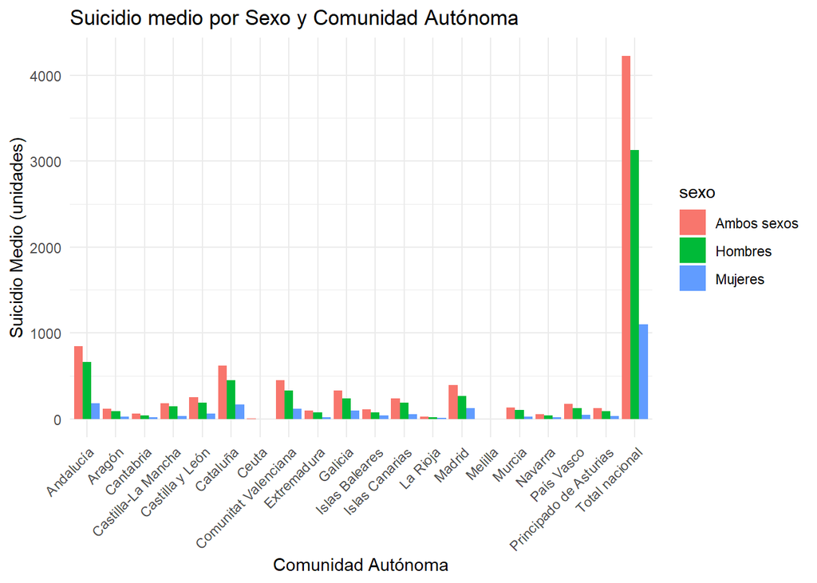

Gráfica de consumo de alcohol medio por sexo y comunidad autónoma.

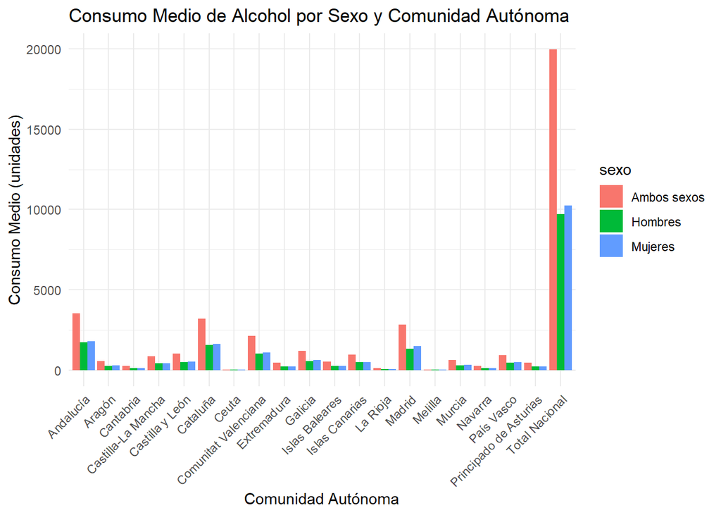